# Density estimation. Clustering.

Pedro Delicado

## Reading the data: Boston Housing

We’ll use the `MASS::Boston` dataset, that contains median house values from Boston neighbourhoods. In particular we are interested in the joint distributions of centered and scaled variables `lstat` and `rm`:

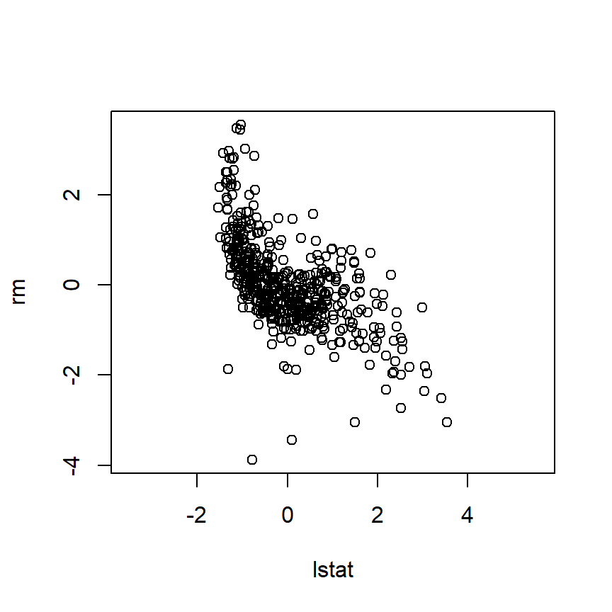

```r
data("Boston", package = "MASS")
X <- scale(Boston[,c(13,6)])
plot(X,asp=1)
```

## Questions

1. We want to estimate the joint bivariate density using a kernel estimator with the same bandwith in both dimensions: $h=(a,a)$. For instance, the following code performs this estimation for $a=0.5$:

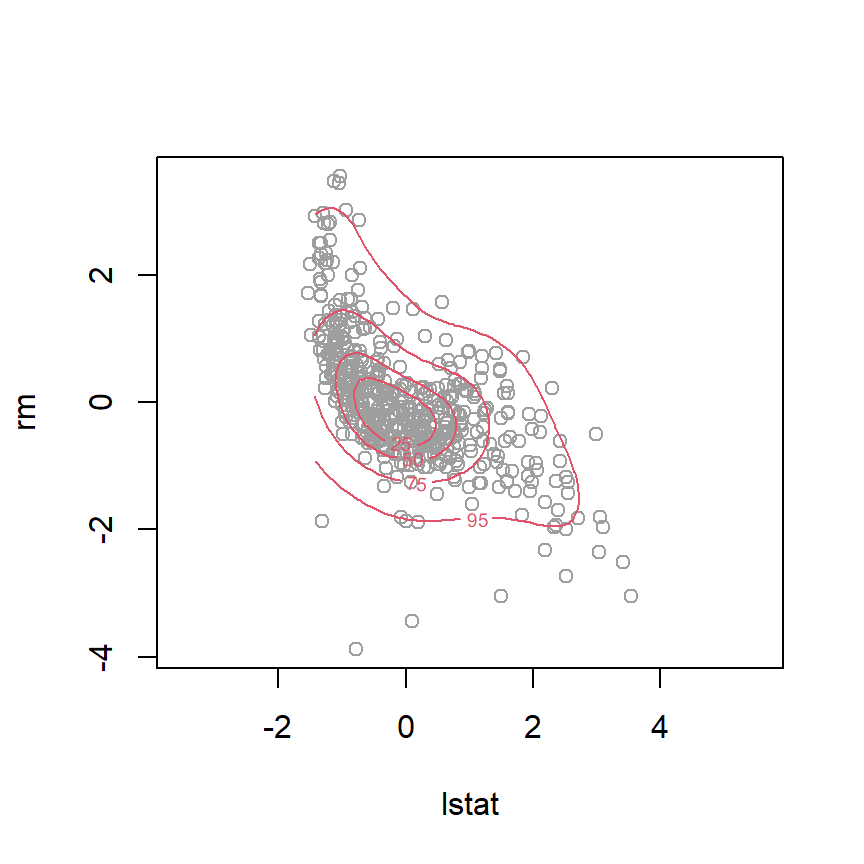

```r
library(sm)
plot(X,asp=1,col=8)
sm.density(X,h=.5*c(1,1),display="slice",props=c(25,50,75,95),col=2,add=TRUE)
```

Use the *maximum log-likelihood cross-validation method* for choosing the value of $a$, whem $a$ takes values in the vector `seq(0.1,1,by=0.1)`. Then repeat the previous density estimation using the chosen value of $a$.

*Indication:* Maximize in $a$ the **logarithm** of the likelihood cross-validation (instead of maximizing just the likelihood cross-validation). The following code evaluates the logarithm of the density estimator at point $(0,0)$:

```r
new.point <- matrix(c(0,0),ncol=2)
f.hat <- sm.density(X,h=.5*c(1,1),display="none",eval.grid=FALSE,
                    eval.points=new.point)
log(f.hat$estimate)
```

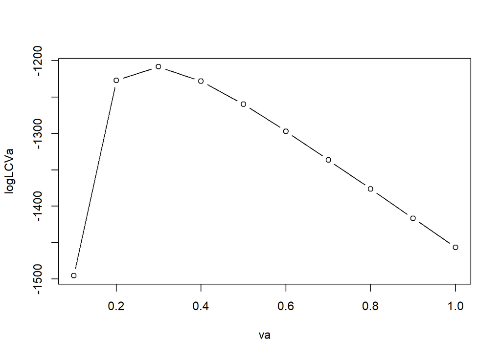

```r
va <- seq(0.1,1,by=0.1)
na <- length(va)
logLCVa <- numeric(na)

n <- dim(X)[1]

for (j in 1:na){
  a <- va[j]
  for (i in 1:n){
    new.point <- matrix(X[i,],ncol=2)
    f.hat.i <- sm.density(X[-i,],h=a*c(1,1),display="none",eval.grid=FALSE,
                    eval.points=new.point)$estimate
    logLCVa[j] <- logLCVa[j] + log(f.hat.i)
  }
}

plot(va,logLCVa,type="b")
```

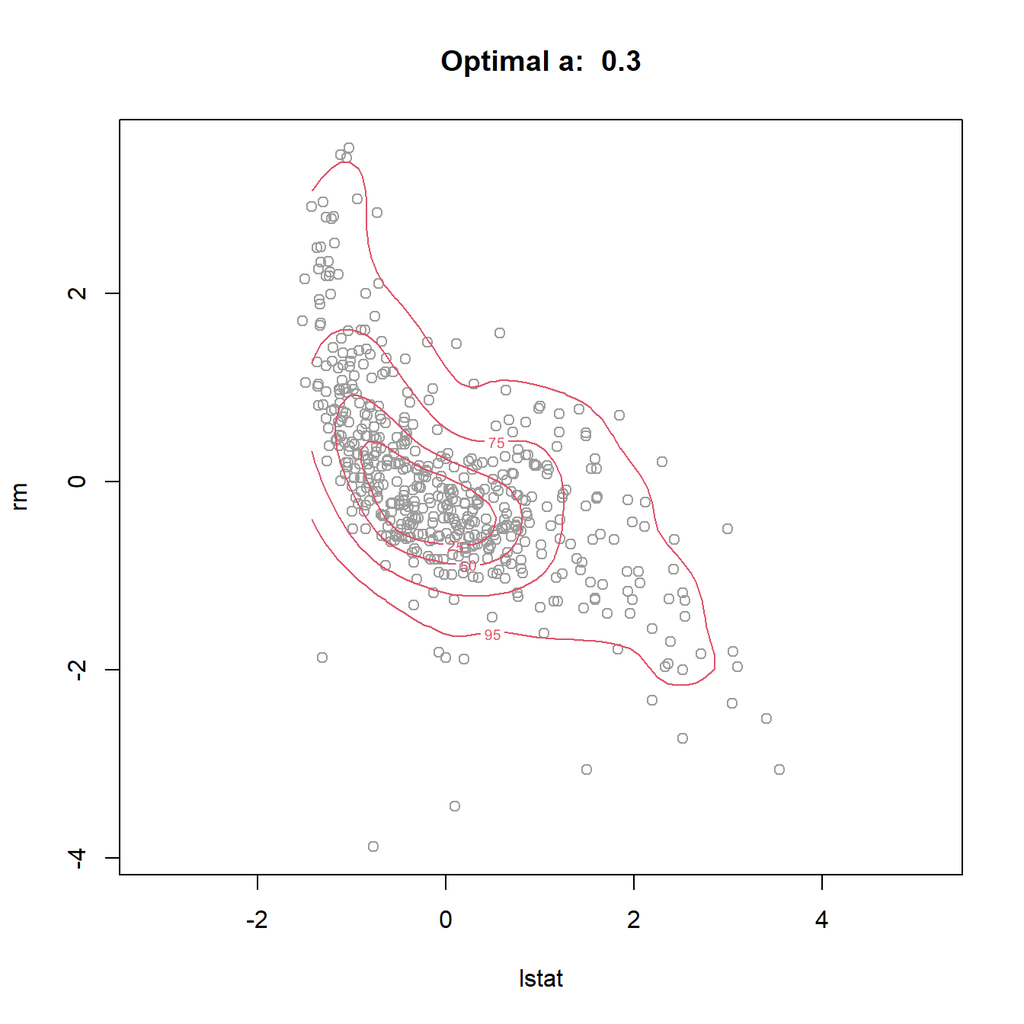

```r
a.opt <- va[which.max(logLCVa)]

plot(X,asp=1,col=8,main=paste("Optimal a: ",a.opt))
sm.density(X,h=a.opt*c(1,1),display="slice",props=c(25,50,75,95),col=2,add=TRUE)
```

2. Do a model based clustering of these data assuming a Gaussian Mixture Model with $k=3$ classes. Plot the scatterplot of the data, using a different color for points in different clusters. Use library `mclust`.

```r
k<-3
library(mclust)
GMM_3 <- Mclust(X,G=3)
clust.ind <- GMM_3$classification
summary(GMM_3,parameters=TRUE)
```

```
FALSE ----------------------------------------------------
FALSE Gaussian finite mixture model fitted by EM algorithm
FALSE ----------------------------------------------------
FALSE
FALSE Mclust VVV (ellipsoidal, varying volume, shape, and orientation) model with 3
FALSE components:
FALSE
FALSE  log-likelihood   n df       BIC       ICL
FALSE       -1164.321 506 17 -2434.493 -2638.818
FALSE
FALSE Clustering table:
FALSE   1   2   3
FALSE 167 239 100
FALSE
FALSE Mixing probabilities:
FALSE         1         2         3
FALSE 0.3242434 0.4607133 0.2150433
FALSE
FALSE Means:
FALSE             [,1]        [,2]       [,3]
FALSE lstat -0.8865668 -0.02333019  1.3867530
FALSE rm     0.7236313 -0.30035890 -0.4475998
FALSE
FALSE Variances:
FALSE [,,1]
FALSE            lstat         rm
FALSE lstat  0.1192626 -0.2470045
FALSE rm    -0.2470045  1.3535331
FALSE [,,2]
FALSE            lstat         rm
FALSE lstat  0.2992485 -0.1356198
FALSE rm    -0.1356198  0.1958373
FALSE [,,3]
FALSE            lstat         rm
FALSE lstat  0.7107093 -0.6126909
FALSE rm    -0.6126909  0.9974302
```

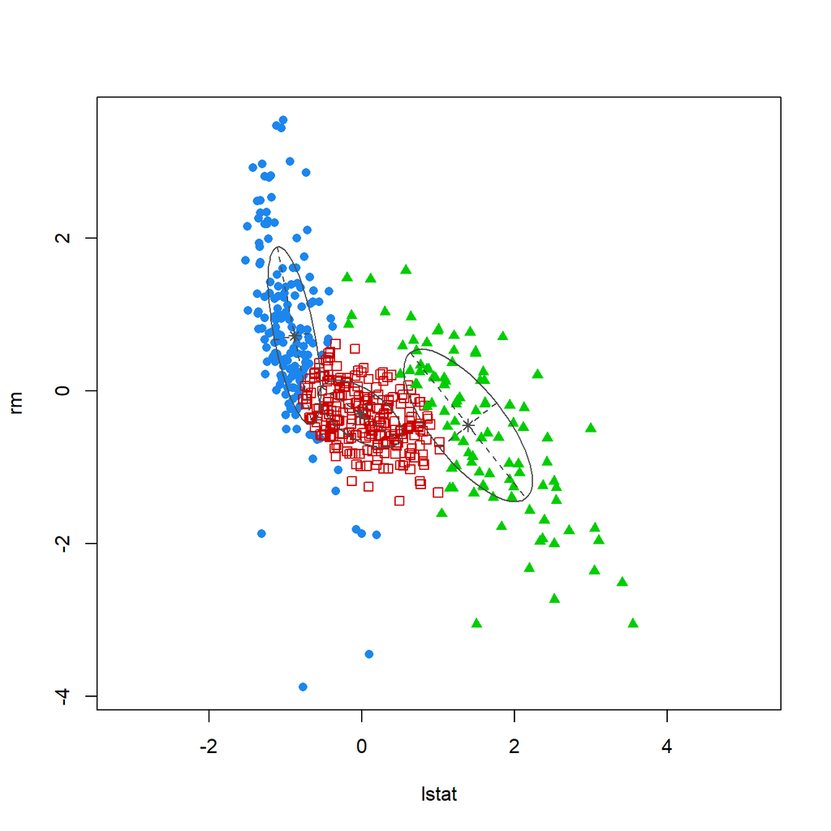

```r
plot(GMM_3, what="classification",asp=1)
```

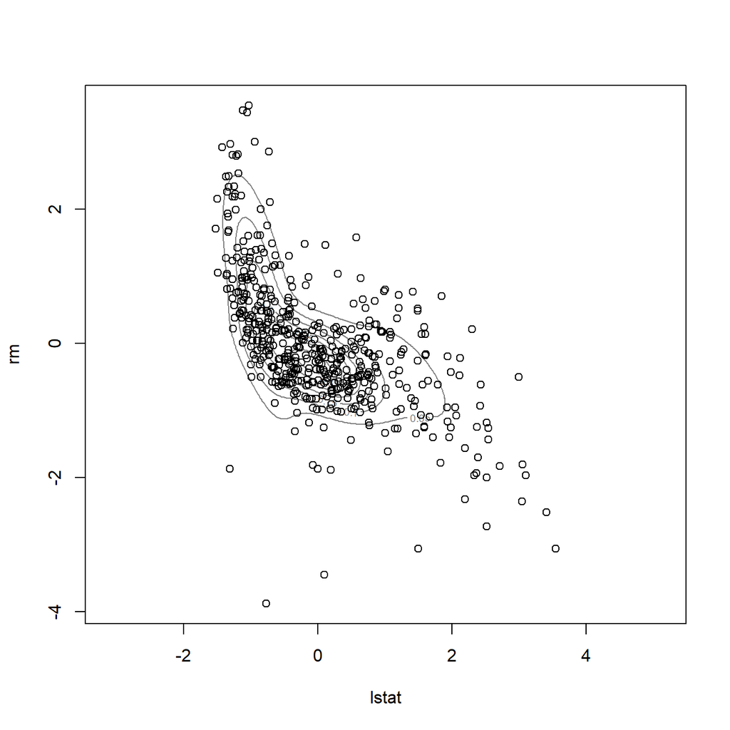

```r
plot(GMM_3, what="density",asp=1)
points(X)
```

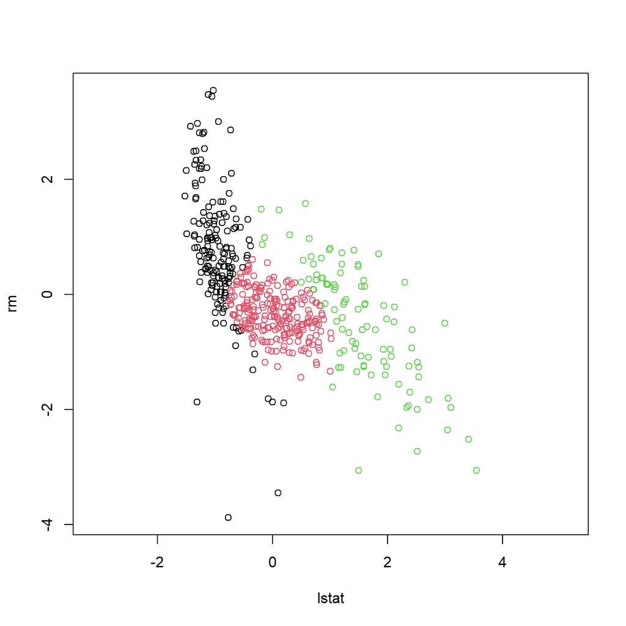

```r
plot(X,col=clust.ind,asp=1)
```

3. For each one of the $k$ clusters obtained above, do the following tasks *(A unique plot should be done, at which the $k$ densities are represented simultaneously)*:
- Consider the bivariate data set of the points in this cluster.
- Estimate non-parametrically the joint density of `lstat` and `rm`, conditional to this cluster *(Use the optimal bandwith found in the first point)*.
- Represent the estimated bivariate density using the level curve that covers the 75% of the points in this cluster.

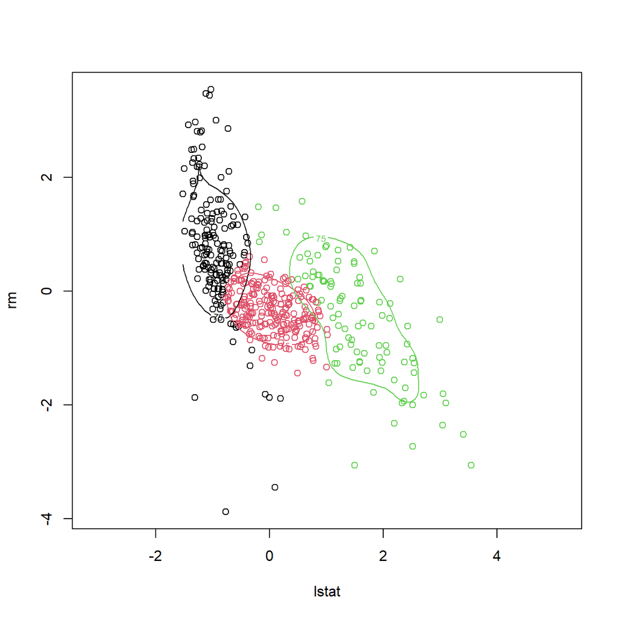

```r
library(sm)
plot(X,col=clust.ind,asp=1)
for (j in 1:k){
  cl.j <- (clust.ind==j)
  sm.density(X[cl.j,],h=a.opt*c(1,1),
             display="slice",props=c(75),
             col=j, cex=4, add=TRUE)
}
```

4. Choose the best number of clusters $k\in\{2,\ldots,6\}$ according to BIC.

```r
GMM_BIC <- Mclust(X,G=2:6)
summary(GMM_BIC,parameters=TRUE)
```

```
FALSE ----------------------------------------------------
FALSE Gaussian finite mixture model fitted by EM algorithm
FALSE ----------------------------------------------------
FALSE
FALSE Mclust VVV (ellipsoidal, varying volume, shape, and orientation) model with 3
FALSE components:
FALSE
FALSE  log-likelihood   n df       BIC       ICL
FALSE       -1164.321 506 17 -2434.493 -2638.818
FALSE
FALSE Clustering table:
FALSE   1   2   3
FALSE 167 239 100
FALSE
FALSE Mixing probabilities:
FALSE         1         2         3
FALSE 0.3242434 0.4607133 0.2150433
FALSE
FALSE Means:
FALSE             [,1]        [,2]       [,3]
FALSE lstat -0.8865668 -0.02333019  1.3867530
FALSE rm     0.7236313 -0.30035890 -0.4475998
FALSE
FALSE Variances:
FALSE [,,1]
FALSE            lstat         rm
FALSE lstat  0.1192626 -0.2470045
FALSE rm    -0.2470045  1.3535331
FALSE [,,2]
FALSE            lstat         rm
FALSE lstat  0.2992485 -0.1356198
FALSE rm    -0.1356198  0.1958373
FALSE [,,3]
FALSE            lstat         rm
FALSE lstat  0.7107093 -0.6126909
FALSE rm    -0.6126909  0.9974302
```

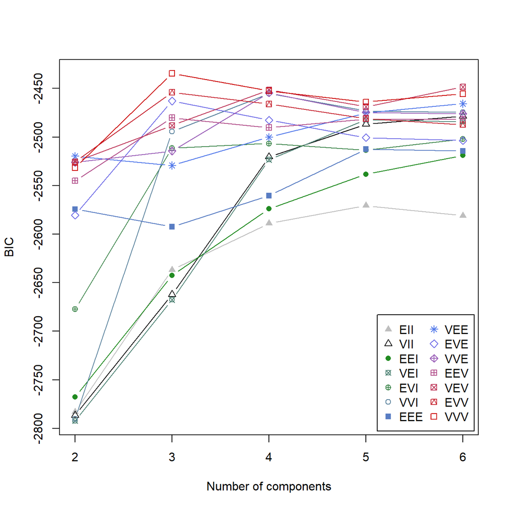

```r
plot(GMM_BIC, what="BIC",asp=1)
```

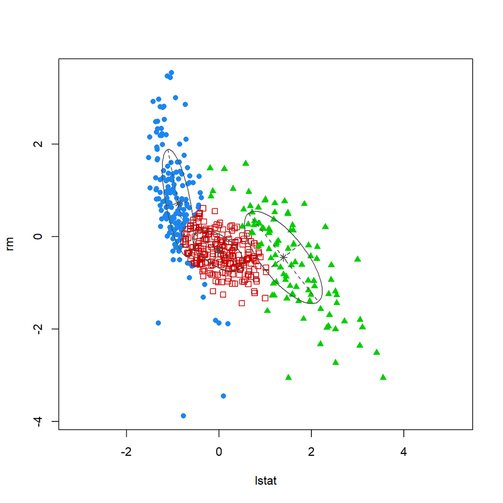

```r
plot(GMM_BIC, what="classification",asp=1)
```

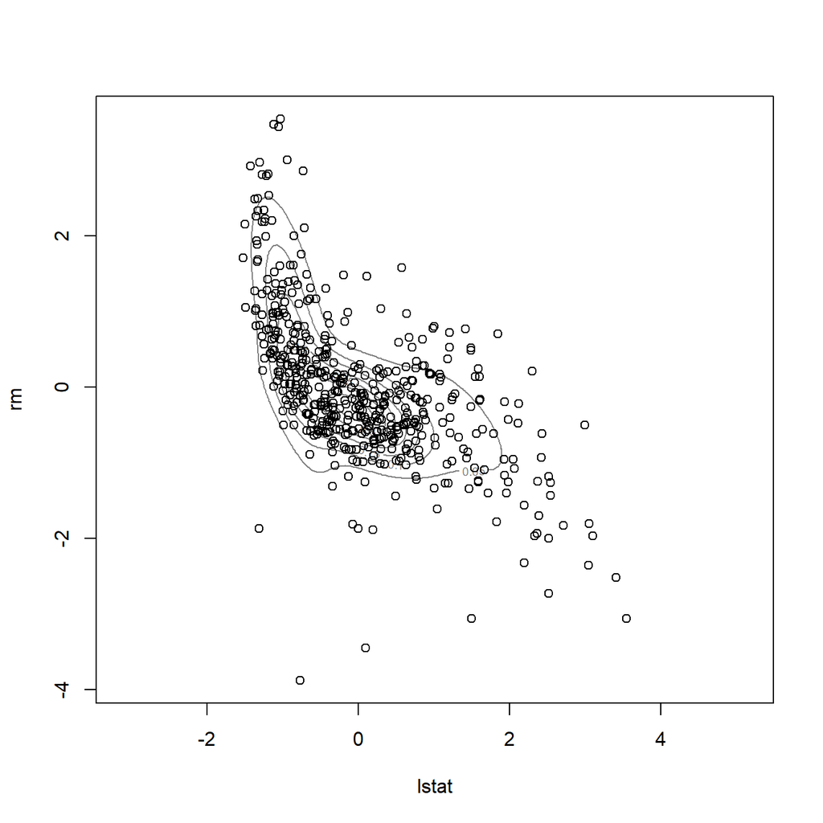

```r
plot(GMM_BIC, what="density",asp=1)
points(X)
```